# Personal Knowledge Management — What, Why and How?

> *Organised common (or uncommon) sense – very basic knowledge is an enormously powerful tool… You have to have a temperament to grab ideas and do sensible things. [Charlie Munger]*

> *I have always imagined that Paradise will be a kind of library. [Jorge Luis Borges]*

> *Knowledge has to be improved, challenged, and increased constantly, or it vanishes [Peter F. Drucker]*

### What is PKM?

Here is what I got from [Wikipedia](https://en.wikipedia.org/wiki/Personal_knowledge_management):

> *Personal knowledge management (PKM) is a collection of processes that a person uses to gather, classify, store, search, retrieve, and share knowledge in his or her daily activities and the way in which these processes support work activities. [Wikipedia]*

But I have my version of definition:

> *Personal knowledge management (PKM) is a collection of processes that a person **manages information, extracts and refines knowledge, share with others, uses knowledge to do sensible things and breaks boundaries between disciplines**. [Hui]*

### Why PKM?

It takes me very long time to realize I badly need PKM. I love books (learning) which has been the case since I can remember. However, I was not on purposely selective about what I read. As a random reader, I went to a bookstore, randomly picked book and read whatever seemed to interest me at that time. Or sometimes my friends recommended book to me. It actually has been my attitude towards many other things: choose from whatever come to me that seemed interest me instead of **knowing what I really want and go to get it**. Unfortunately, I am happened to be the kind of person who is interested in a million things under the sun. I randomly tried new things that I thought were interesting as if I would never die. It is not hard to imagine how I get myself in trouble…What made me think I need to change? It goes back to Apr 2012 when a friend and I founded a statistical consulting company that provides statistical training and consulting in Beijing. One year later, both of us quitted and handed it to someone else for different reasons. Actually I was extremely passionated about running the business at that time but I was very unhappy and anxious. I became a terrible stranger, someone not loving. Later I read about [focusing illusion](https://www.edge.org/response-detail/11984) which may explain my situation at that time. I could hear God saying: “Hui, stop and think about what you really want.” So I did.

> *Our happiness is thus not affected to a large extent by reflecting on our lives, but by the flood of feelings that are constantly generated within us. [“The Optimism Bias” by Tali Sharot]*

Anyway, I learnt a lot from the experience. Here I just want to mention three learnings that are related to PKM:

1. There are big gaps among:

   > Information —> Knowledge —> Skill
2. I have to be selective: figure out what I want then go to get it
3. I need to put effort on building **Mental Framework**

What is mental framework? It is what Charlie Munger calls **Latticework of Mental Models**:

> *You have to learn all the big ideas in the key disciplines in a way that they’re in a mental latticework in your head and you automatically use them for the rest of your life. If you do that, I solemnly promise you that one day you’ll be walking down the street and you’ll look to your right and left and you’ll think “my heavenly days, I’m now one of the few competent people in my whole age cohort.” If you don’t do it, many of the brightest of you will live in the middle ranks or in the shallows. [Charlie Munger]*

Reading itself is not enough: you have to be able to grab key ideas and make sense of them. In order to found a sound framework:

- You have to learn different disciplines (as many as you can)
- Put effort on extracting the most important and basic concepts in every discipline and start to learn pattern

Once you have a framework, you can do something we call [触类旁通](http://dictionary.pinpinchinese.com/definitions/t/觸類旁通-chuleipangtong) in Chinese. Personal Knowledge Management, in my opinion, is a way to build Mental Framework. It aims at:

1. Learn a set of strong, useful concepts from each discipline and tie them together in such a way that **the whole is greater than the sum of the parts**.
2. Know **the edge of our competency**, know that there is **much larger part of the world we don’t know**.
3. Be able to tell what we can do, what we can’t; what is important, what is not. And do the **important things that we can do**.

### How PKM?

PKM needs time to develop and I told myself to be patient. Here is my PKM MindMap (yours can be different):

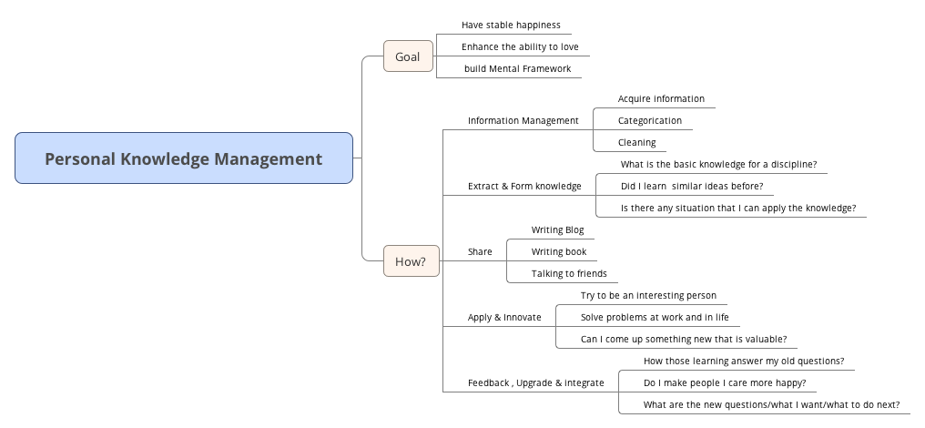

Let’s start from Personal Information Management (PIM). I have been working on it since 2015 and [here](http://hui1987.com/) is the result. In terms of the process, I break it down to three steps:

#### Gather information

There are many information sources (book, magazines, news paper, radio, internet…). Here are my personal opinions.

- Use book as the main source and be “picky” about book. I prefer books prodiving **core knowledge**. Let me further explain the two kinds of knowledge:
  1. I call **“hot knowledge”** which is corresponding to specific concept and hard to generalize to other disciplines or bigger scope. Books of these kind includes novels, essays, news articles etc. I hope you get the point.
  2. I call **“core knowledge”** which is basic knowledge related to humanity or the mechanism our brain works. Those knowledge can be easily used across disciplines and guide us in different ways. For example, mathematics, psychology, social study, brain research, classic philosophy, logic thinking.
- Official WeChat account subscriptions. Information from mobile internet is fragment but it helps me to keep updated on the development of some areas in China.
- Avoid random browsing online which can be a black hole. Make sure you know what you want and direct search for it.